[figure not shown]

# Artificial Intelligence and Machine Learning

# Cars4U Project

# Ravi Potlachervu

[figure not shown]

# Objective

Cars4u is a startup based in India focused on car sales. The objective is to come up with a pricing model that can effectively predict the price of used cars and can help the business in devising profitable strategies using differential pricing.

- Perform predata processing.
- Perform EDA(Explortary Data Analysis )
- Perform univariate and multivatiate analyses.
- Build Linear Regression model to predict price of used cars.
- Generate a set of insights and recommendations.

# Dataset:

- **S.No** : Serial number.
- **Name**: Name of the car which includes brand name and model name.
- **Location**: Location in which the car is being sold or is available for purchase (cities).
- **Year**: Manufacturing year of the car.
- **Kilometers_driven**: The total kilometers driven in the car by the previous owner(s) in km.
- **Fuel_Type**: The type of fuel used by the car (Petrol, Diesel, Electric, CNG, LPG).
- **Transmission**: The type of transmission used by the car (Automatic/Manual).
- **Owner**: Type of ownership.
- **Mileage**: The standard mileage offered by the car company in kmpl or km/kg.
- **Engine**: The displacement volume of the engine in CC.
- **Power**: The maximum power of the engine in bhp.
- **Seats**: The number of seats in the car.
- **New_Price**: The price of a new car of the same model in INR Lakhs (1 Lakh INR = 100,000 INR).
- **Price**: The price of the used car in INR Lakhs.

### Data Preprocessing

**Importing required libraries**

```python
# Libraries to help with reading and manipulating data
import numpy as np
import pandas as pd

# Libraries to help with data visualization
import matplotlib.pyplot as plt
import seaborn as sns

sns.set()

# Removes the limit for the number of displayed columns
pd.set_option("display.max_columns", None)
# Sets the limit for the number of displayed rows
pd.set_option("display.max_rows", 200)

# to split the data into train and test
from sklearn.model_selection import train_test_split

# to build linear regression_model
from sklearn.linear_model import LinearRegression

# to check model performance
from sklearn.metrics import mean_absolute_error, mean_squared_error, r2_score
```

**Import the dataset**

```python
#Read dataset using panda function read_csv
data = pd.read_csv("used_cars_data.csv")
```

**Understand the Dataset**

Let's start by performing basic steps to understand the data such as:

- Review first and last few rows of the dataset.
- Total no of rows and columns information.
- Identify data types of the columns
- checking the statistical summary

**Review first and last few rows of the dataset**

```python
#Display first few rows of the dataset
data.head()
```

|  | S.No. | Name | Location | Year | Kilometers_Driven | Fuel_Type | Transmission | Owner_Type | Mileage | Engine | Power | Seats | New_Price | Price |
| --- | --- | --- | --- | --- | --- | --- | --- | --- | --- | --- | --- | --- | --- | --- |
| 0 | 0 | Maruti Wagon R LXI CNG | Mumbai | 2010 | 72000 | CNG | Manual | First | 26.6 km/kg | 998 CC | 58.16 bhp | 5.0 | 5.51 | 1.75 |
| 1 | 1 | Hyundai Creta 1.6 CRDi SX Option | Pune | 2015 | 41000 | Diesel | Manual | First | 19.67 kmpl | 1582 CC | 126.2 bhp | 5.0 | 16.06 | 12.50 |
| 2 | 2 | Honda Jazz V | Chennai | 2011 | 46000 | Petrol | Manual | First | 18.2 kmpl | 1199 CC | 88.7 bhp | 5.0 | 8.61 | 4.50 |
| 3 | 3 | Maruti Ertiga VDI | Chennai | 2012 | 87000 | Diesel | Manual | First | 20.77 kmpl | 1248 CC | 88.76 bhp | 7.0 | 11.27 | 6.00 |
| 4 | 4 | Audi A4 New 2.0 TDI Multitronic | Coimbatore | 2013 | 40670 | Diesel | Automatic | Second | 15.2 kmpl | 1968 CC | 140.8 bhp | 5.0 | 53.14 | 17.74 |

The dataset loaded without any issues

- *Dataset is in combination both numerical and String values*
- *'Milage, Engine, Power' columns have values with connected numerical and String values*

```python
#Display last few rows of the dataset
data.tail()
```

|  | S.No. | Name | Location | Year | Kilometers_Driven | Fuel_Type | Transmission | Owner_Type | Mileage | Engine | Power | Seats | New_Price | Price |
| --- | --- | --- | --- | --- | --- | --- | --- | --- | --- | --- | --- | --- | --- | --- |
| 7248 | 7248 | Volkswagen Vento Diesel Trendline | Hyderabad | 2011 | 89411 | Diesel | Manual | First | 20.54 kmpl | 1598 CC | 103.6 bhp | 5.0 | 13.23 | NaN |
| 7249 | 7249 | Volkswagen Polo GT TSI | Mumbai | 2015 | 59000 | Petrol | Automatic | First | 17.21 kmpl | 1197 CC | 103.6 bhp | 5.0 | 10.15 | NaN |
| 7250 | 7250 | Nissan Micra Diesel XV | Kolkata | 2012 | 28000 | Diesel | Manual | First | 23.08 kmpl | 1461 CC | 63.1 bhp | 5.0 | 9.47 | NaN |
| 7251 | 7251 | Volkswagen Polo GT TSI | Pune | 2013 | 52262 | Petrol | Automatic | Third | 17.2 kmpl | 1197 CC | 103.6 bhp | 5.0 | 10.15 | NaN |
| 7252 | 7252 | Mercedes-Benz E-Class 2009-2013 E 220 CDI Avan... | Kochi | 2014 | 72443 | Diesel | Automatic | First | 10.0 kmpl | 2148 CC | 170 bhp | 5.0 | 86.97 | NaN |

- *Observing last few row reveal, there are missing values on price column.*

**Total no of rows and columns information.**

```python
# checking the shape of the data using f-string
print(f"There are {data.shape[0]} rows and {data.shape[1]} columns.")
```

```
There are 7253 rows and 14 columns.
```

```python
# Lets view sample using sample function with random_state parameter
data.sample(10, random_state=2)
```

|  | S.No. | Name | Location | Year | Kilometers_Driven | Fuel_Type | Transmission | Owner_Type | Mileage | Engine | Power | Seats | New_Price | Price |
| --- | --- | --- | --- | --- | --- | --- | --- | --- | --- | --- | --- | --- | --- | --- |
| 4584 | 4584 | Tata Tigor 1.05 Revotorq XT | Kochi | 2018 | 28973 | Diesel | Manual | First | 24.7 kmpl | 1047 CC | 69 bhp | 5.0 | 7.15 | 6.64 |
| 6505 | 6505 | Volkswagen Vento Diesel Highline | Chennai | 2011 | 76041 | Diesel | Manual | First | 20.54 kmpl | 1598 CC | 103.6 bhp | 5.0 | 13.23 | NaN |
| 3675 | 3675 | Maruti Swift VDI | Ahmedabad | 2012 | 65000 | Diesel | Manual | First | 22.9 kmpl | 1248 CC | 74 bhp | 5.0 | 7.88 | 3.90 |
| 5654 | 5654 | Hyundai i20 Magna Optional 1.2 | Kochi | 2014 | 42315 | Petrol | Manual | First | 18.5 kmpl | 1197 CC | 82.9 bhp | 5.0 | 10.25 | 4.79 |
| 4297 | 4297 | Toyota Camry 2.5 G | Mumbai | 2014 | 68400 | Petrol | Automatic | First | 12.98 kmpl | 2494 CC | 178.4 bhp | 5.0 | 40.62 | 13.50 |
| 2603 | 2603 | Mercedes-Benz New C-Class 220 CDI AT | Jaipur | 2010 | 74213 | Diesel | Automatic | First | 14.84 kmpl | 2143 CC | 170 bhp | 5.0 | 49.49 | 11.50 |
| 4337 | 4337 | Volkswagen Vento Petrol Highline AT | Kochi | 2014 | 32283 | Petrol | Automatic | Second | 14.4 kmpl | 1598 CC | 103.6 bhp | 5.0 | 13.23 | 5.41 |
| 6625 | 6625 | Maruti Swift VDI BSIV | Kolkata | 2012 | 72000 | Diesel | Manual | First | 17.8 kmpl | 1248 CC | NaN | 5.0 | 7.88 | NaN |
| 2846 | 2846 | Skoda Superb Elegance 1.8 TSI AT | Kochi | 2011 | 73783 | Petrol | Automatic | Second | 13.7 kmpl | 1798 CC | 157.75 bhp | 5.0 | 33.36 | 5.23 |
| 1237 | 1237 | Audi Q3 2.0 TDI Quattro | Hyderabad | 2013 | 60000 | Diesel | Automatic | First | 17.32 kmpl | 1968 CC | 184 bhp | 5.0 | 44.80 | 21.00 |

```python
#Lets create copy original data
df=data.copy()
```

**Get the datatype information of the columns**

```python
#check data types of columns
df.info()
```

```
<class 'pandas.core.frame.DataFrame'>
RangeIndex: 7253 entries, 0 to 7252
Data columns (total 14 columns):
 #   Column             Non-Null Count  Dtype
---  ------             --------------  -----
 0   S.No.              7253 non-null   int64
 1   Name               7253 non-null   object
 2   Location           7253 non-null   object
 3   Year               7253 non-null   int64
 4   Kilometers_Driven  7253 non-null   int64
 5   Fuel_Type          7253 non-null   object
 6   Transmission       7253 non-null   object
 7   Owner_Type         7253 non-null   object
 8   Mileage            7251 non-null   object
 9   Engine             7207 non-null   object
 10  Power              7078 non-null   object
 11  Seats              7200 non-null   float64
 12  New_Price          7253 non-null   float64
 13  Price              6019 non-null   float64
dtypes: float64(3), int64(3), object(8)
memory usage: 793.4+ KB
```

**Checking for duplicate values in the dataset**

```python
#lets check duplicate values
df.duplicated().sum()
```

```
0
```

**Checking for missing values in the data**

```python
# Lets check missing values in the dataframe
df.isnull().sum()
```

```
S.No.                   0
Name                    0
Location                0
Year                    0
Kilometers_Driven       0
Fuel_Type               0
Transmission            0
Owner_Type              0
Mileage                 2
Engine                 46
Power                 175
Seats                  53
New_Price               0
Price                1234
dtype: int64
```

- This confirms there are missing values under Engine(46),Mileage(2), Power(175),Seats(53) and Price(1234) columns.

### We will drop the missing values in `Price` column as it is the dependent variable.

```python
#Drop missing values in Price column
df.dropna(subset=["Price"], inplace=True)
```

```python
#reindex the dataframe
df.reset_index(inplace=True, drop=True)
```

```python
#Lets drop "S.No" column
df.drop(['S.No.'], axis=1,inplace=True)
```

```python
#check data types of columns
df.info()
```

```
<class 'pandas.core.frame.DataFrame'>
RangeIndex: 6019 entries, 0 to 6018
Data columns (total 13 columns):
 #   Column             Non-Null Count  Dtype
---  ------             --------------  -----
 0   Name               6019 non-null   object
 1   Location           6019 non-null   object
 2   Year               6019 non-null   int64
 3   Kilometers_Driven  6019 non-null   int64
 4   Fuel_Type          6019 non-null   object
 5   Transmission       6019 non-null   object
 6   Owner_Type         6019 non-null   object
 7   Mileage            6017 non-null   object
 8   Engine             5983 non-null   object
 9   Power              5876 non-null   object
 10  Seats              5977 non-null   float64
 11  New_Price          6019 non-null   float64
 12  Price              6019 non-null   float64
dtypes: float64(3), int64(2), object(8)
memory usage: 611.4+ KB
```

**Checking for missing values in the data**

```python
# Lets check missing values in the dataframe after dropping S.No. column
df.isnull().sum()
```

```
Name                   0
Location               0
Year                   0
Kilometers_Driven      0
Fuel_Type              0
Transmission           0
Owner_Type             0
Mileage                2
Engine                36
Power                143
Seats                 42
New_Price              0
Price                  0
dtype: int64
```

**Checking for duplicate values in the dataset**

```python
# Lets check duplicate values after dropping S.No. column.
df.duplicated().sum()
```

```
0
```

- There are 0 duplicate values in the dataset.

```python
# checking the shape of the data after dropping duplicate row using f-string
print(f"There are {df.shape[0]} rows and {df.shape[1]} columns after dropping duplicates.")
```

```
There are 6019 rows and 13 columns after dropping duplicates.
```

**Getting the statistical summary for the dataset**

```python
df.describe(include='all').T
```

|  | count | unique | top | freq | mean | std | min | 25% | 50% | 75% | max |
| --- | --- | --- | --- | --- | --- | --- | --- | --- | --- | --- | --- |
| Name | 6019 | 1876 | Mahindra XUV500 W8 2WD | 49 | NaN | NaN | NaN | NaN | NaN | NaN | NaN |
| Location | 6019 | 11 | Mumbai | 790 | NaN | NaN | NaN | NaN | NaN | NaN | NaN |
| Year | 6019.0 | NaN | NaN | NaN | 2013.358199 | 3.269742 | 1998.0 | 2011.0 | 2014.0 | 2016.0 | 2019.0 |
| Kilometers_Driven | 6019.0 | NaN | NaN | NaN | 58738.380296 | 91268.843206 | 171.0 | 34000.0 | 53000.0 | 73000.0 | 6500000.0 |
| Fuel_Type | 6019 | 5 | Diesel | 3205 | NaN | NaN | NaN | NaN | NaN | NaN | NaN |
| Transmission | 6019 | 2 | Manual | 4299 | NaN | NaN | NaN | NaN | NaN | NaN | NaN |
| Owner_Type | 6019 | 4 | First | 4929 | NaN | NaN | NaN | NaN | NaN | NaN | NaN |
| Mileage | 6017 | 442 | 18.9 kmpl | 172 | NaN | NaN | NaN | NaN | NaN | NaN | NaN |
| Engine | 5983 | 146 | 1197 CC | 606 | NaN | NaN | NaN | NaN | NaN | NaN | NaN |
| Power | 5876 | 371 | 74 bhp | 235 | NaN | NaN | NaN | NaN | NaN | NaN | NaN |
| Seats | 5977.0 | NaN | NaN | NaN | 5.278735 | 0.80884 | 0.0 | 5.0 | 5.0 | 5.0 | 10.0 |
| New_Price | 6019.0 | NaN | NaN | NaN | 21.499855 | 24.332922 | 3.91 | 7.88 | 11.3 | 21.77 | 375.0 |
| Price | 6019.0 | NaN | NaN | NaN | 9.479468 | 11.187917 | 0.44 | 3.5 | 5.64 | 9.95 | 160.0 |

**Review the count and percentage of categorical levels in each column**

```python
# Printing the count of unique categorical levels in each column
cat_var = ['Name','Location','Year','Fuel_Type','Transmission','Owner_Type','Seats']
for column in cat_var:
    print(df[column].value_counts(dropna=False))
    print("-" * 50)
```

```
Mahindra XUV500 W8 2WD           49
Maruti Swift VDI                 45
Honda City 1.5 S MT              34
Maruti Swift Dzire VDI           34
Maruti Swift VDI BSIV            31
                                 ..
Ford Fiesta Titanium 1.5 TDCi     1
Mahindra Scorpio S10 AT 4WD       1
Hyundai i20 1.2 Era               1
Toyota Camry W4 (AT)              1
Mahindra Xylo D4 BSIV             1
Name: Name, Length: 1876, dtype: int64
--------------------------------------------------
Mumbai        790
Hyderabad     742
Kochi         651
Coimbatore    636
Pune          622
Delhi         554
Kolkata       535
Chennai       494
Jaipur        413
Bangalore     358
Ahmedabad     224
Name: Location, dtype: int64
--------------------------------------------------
2014    797
2015    744
2016    741
2013    649
2017    587
2012    580
2011    466
2010    342
2018    298
2009    198
2008    174
2007    125
2019    102
2006     78
```

[output cut: 24 more lines]

```
Fourth & Above       9
Name: Owner_Type, dtype: int64
--------------------------------------------------
5.0     5014
7.0      674
8.0      134
4.0       99
NaN       42
6.0       31
2.0       16
10.0       5
9.0        3
0.0        1
Name: Seats, dtype: int64
--------------------------------------------------
```

```python
for column in cat_var:
    print(df[column].value_counts(normalize=True))
    print("-" * 50)
```

[output not shown]

[output cut: 24 more lines]

```
Third             0.018891
Fourth & Above    0.001655
Name: Owner_Type, dtype: float64
--------------------------------------------------
5.0     0.839839
7.0     0.110571
8.0     0.023614
4.0     0.016530
6.0     0.005279
2.0     0.002500
10.0    0.001111
9.0     0.000417
0.0     0.000139
Name: Seats, dtype: float64
--------------------------------------------------
```

**Observations**

```python
df.head()
```

|  | Name | Location | Year | Kilometers_Driven | Fuel_Type | Transmission | Owner_Type | Mileage | Engine | Power | Seats | New_Price | Price |
| --- | --- | --- | --- | --- | --- | --- | --- | --- | --- | --- | --- | --- | --- |
| 0 | Maruti Wagon R LXI CNG | Mumbai | 2010 | 72000 | CNG | Manual | First | 26.6 km/kg | 998 CC | 58.16 bhp | 5.0 | 5.51 | 1.75 |
| 1 | Hyundai Creta 1.6 CRDi SX Option | Pune | 2015 | 41000 | Diesel | Manual | First | 19.67 kmpl | 1582 CC | 126.2 bhp | 5.0 | 16.06 | 12.50 |
| 2 | Honda Jazz V | Chennai | 2011 | 46000 | Petrol | Manual | First | 18.2 kmpl | 1199 CC | 88.7 bhp | 5.0 | 8.61 | 4.50 |
| 3 | Maruti Ertiga VDI | Chennai | 2012 | 87000 | Diesel | Manual | First | 20.77 kmpl | 1248 CC | 88.76 bhp | 7.0 | 11.27 | 6.00 |
| 4 | Audi A4 New 2.0 TDI Multitronic | Coimbatore | 2013 | 40670 | Diesel | Automatic | Second | 15.2 kmpl | 1968 CC | 140.8 bhp | 5.0 | 53.14 | 17.74 |

- There are some anamolies on unit values on Mileage column, we will find if there are any unusual units on Mileage, Engine and Power columns.

### From the above observation, we see that in the data some columns need to be preprocessed before start our analysis.

## Data Preprocessing

### Columns containing mesuring units

Engine, Mileage, Power have mesuring units with string identifiy them as object, lets trim unit character and convert to numerical datatypes and replace null valules with nan.

```python
#lets remove units string for Mileage, Engine and Power columns by spliting data at first occurance of space.
df['Mileage'] = df["Mileage"].str.split().str[0]
df['Power'] = df["Power"].str.split().str[0]
df['Engine'] = df["Engine"].str.split().str[0]
```

```python
df.head()
```

|  | Name | Location | Year | Kilometers_Driven | Fuel_Type | Transmission | Owner_Type | Mileage | Engine | Power | Seats | New_Price | Price |
| --- | --- | --- | --- | --- | --- | --- | --- | --- | --- | --- | --- | --- | --- |
| 0 | Maruti Wagon R LXI CNG | Mumbai | 2010 | 72000 | CNG | Manual | First | 26.6 | 998 | 58.16 | 5.0 | 5.51 | 1.75 |
| 1 | Hyundai Creta 1.6 CRDi SX Option | Pune | 2015 | 41000 | Diesel | Manual | First | 19.67 | 1582 | 126.2 | 5.0 | 16.06 | 12.50 |
| 2 | Honda Jazz V | Chennai | 2011 | 46000 | Petrol | Manual | First | 18.2 | 1199 | 88.7 | 5.0 | 8.61 | 4.50 |
| 3 | Maruti Ertiga VDI | Chennai | 2012 | 87000 | Diesel | Manual | First | 20.77 | 1248 | 88.76 | 7.0 | 11.27 | 6.00 |
| 4 | Audi A4 New 2.0 TDI Multitronic | Coimbatore | 2013 | 40670 | Diesel | Automatic | Second | 15.2 | 1968 | 140.8 | 5.0 | 53.14 | 17.74 |

- Removed unit string from Milage , Engine and Power columns.
- We will replace null values with np.nan and convert to numerical datatype.

```python
df2=df.copy()
```

```python
df2.Mileage.unique()
```

```
array(['26.6', '19.67', '18.2', '20.77', '15.2', '21.1', '23.08', '11.36',
       '20.54', '22.3', '21.56', '16.8', '25.2', '12.7', '0.0', '13.5',
       '25.8', '28.4', '20.45', '14.84', '22.69', '23.65', '13.53',
       '18.5', '14.4', '20.92', '17.5', '12.8', '19.01', '14.53', '11.18',
       '12.4', '16.09', '14.0', '24.3', '18.15', '11.74', '22.07', '19.7',
       '25.4', '25.32', '14.62', '14.28', '14.9', '11.25', '24.4',
       '16.55', '17.11', '22.9', '17.8', '18.9', '15.04', '25.17',
       '20.36', '13.29', '13.68', '20.0', '15.8', '25.0', '16.4', '24.52',
       '22.1', '8.5', '15.1', '16.95', '19.64', '16.5', '18.53', '17.57',
       '18.0', '23.2', '16.73', '17.0', '13.0', '17.68', '22.7', '16.2',
       '15.26', '23.0', '19.83', '14.94', '17.71', '14.74', '16.0',
       '22.32', '12.99', '23.3', '19.15', '10.8', '15.0', '22.0', '21.9',
       '12.05', '11.7', '21.21', '20.73', '24.07', '19.0', '20.58',
       '19.27', '11.5', '18.6', '21.14', '11.05', '21.76', '7.81',
       '21.66', '17.2', '20.63', '19.4', '14.8', '26.0', '20.4', '21.5',
       '15.3', '17.9', '16.6', '22.54', '25.44', '13.7', '22.48', '12.9',
       '19.98', '21.4', '19.81', '15.4', '25.47', '19.87', '17.45',
       '14.7', '15.64', '15.73', '23.59', '16.1', '27.4', '20.46',
       '15.29', '20.51', '11.8', '14.3', '14.67', '17.19', '21.03',
       '22.5', '16.82', '11.72', '17.4', '17.05', '24.0', '28.09', '20.5',
       '13.1', '19.91', '18.7', '16.38', '11.57', '17.3', '22.95',
       '18.88', '23.4', '22.74', '12.07', '17.1', '18.48', '16.47',
       '23.1', '14.07', '16.02', '19.3', '17.7', '9.52', '14.75', '26.3',
       '11.3', '21.12', '21.02', '14.45', '19.33', '13.8', '24.7', '11.0',
       '11.07', '21.43', '14.21', '18.86', '16.07', '13.49', '20.38',
       '12.0', '17.01', '13.2', '20.37', '15.96', '14.16', '13.17',
       '27.62', '25.1', '15.17', '11.33', '17.92', '12.55', '12.6',
       '17.72', '18.16', '15.68', '15.5', '12.1', '14.83', '17.6', '14.6',
       '14.66', '10.93', '20.68', '9.9', '21.13', '20.14', '19.2', '27.3',
       '16.36', '26.59', '12.5', '13.6', '15.06', '10.13', '17.21',
       '15.97', '10.5', '14.69', '23.9', '19.1', '21.27', '15.9', '20.7',
       '14.1', '20.89', '18.12', '12.3', '19.71', '9.43', '13.4', '13.14',
       '18.1', '22.77', '14.49', '12.39', '10.91', '20.85', '15.63',
       '27.39', '18.3', '16.78', '25.5', '10.0', '13.73', '24.2', '14.02',
       '26.83', '16.77', '24.5', '20.34', '21.7', '9.7', '14.33', '21.64',
       '19.16', '16.93', '9.0', '26.2', '16.3', '12.62', '20.64', '14.24',
       '18.06', '10.2', '10.1', '18.25', '13.93', '25.83', '8.6', '13.24',
       '17.09', '23.84', '8.45', '19.6', '19.5', '20.3', '16.05', '11.2',
       '27.03', '18.78', '12.35', '14.59', '17.32', '14.95', '13.22',
       '23.03', '33.44', '15.6', '19.12', '10.98', '33.54', '16.46',
       '18.4', '11.1', '13.01', '18.8', '16.52', '18.44', '19.49', '23.5',
       '23.8', '12.65', '20.65', '21.72', '12.19', '26.1', '18.33',
       '12.81', '17.06', '17.67', '19.34', '8.3', '16.96', '11.79',
       '20.86', '16.98', '11.68', '15.74', '15.7', '18.49', '10.9',
       '19.59', '11.4', '13.06', '21.0', '15.15', '16.9', '18.23',
       '17.16', '17.43', '19.08', '18.56', '11.9', '24.6', '21.79',
       '12.95', '25.6', '13.45', '26.21', '13.58', '16.25', '10.4',
       '17.44', '22.71', '17.54', '15.87', '9.5', '11.56', '14.39',
       '19.09', '17.85', '31.79', '18.18', '21.19', '21.8', '15.42',
       '14.47', '19.69', '12.83', '8.0', '22.8', '12.63', '14.57',
       '27.28', '15.41', '32.26', '18.19', '13.33', '16.7', '17.84',
       '23.19', '11.49', '18.51', '13.44', '8.7', '8.77', '17.97',
       '23.57', '12.37', '9.1', '12.51', '19.44', '21.38', '16.51',
       '24.8', '14.42', '26.8', '24.04', '9.8', '19.68', '21.2', '19.72',
       '14.2', '12.98', '23.01', '16.12', '9.3', '15.85', nan, '17.88',
       '10.6', '11.78', '7.94', '25.01', '8.1', '13.9', '11.62', '20.62',
       '15.11', '10.37', '18.59', '9.74', '14.81', '8.2', '12.97', '7.5',
       '30.46', '6.4', '12.85', '18.69', '17.24'], dtype=object)
```

```python
df2.Power.unique()
```

```
array(['58.16', '126.2', '88.7', '88.76', '140.8', '55.2', '63.1',
       '171.5', '103.6', '74', '103.25', '116.3', '187.7', '115',
       '175.56', '98.6', '83.8', '167.62', '190', '88.5', '177.01', '80',
       '67.1', '102', '108.45', '138.1', '184', '179.5', '103.5', '64',
       '82', '254.8', '73.9', '46.3', '37.5', '77', '82.9', '149.92',
       '138.03', '112.2', '163.7', '71', '105', '174.33', '75', '103.2',
       '53.3', '78.9', '147.6', '147.8', '68', '186', '170', '69', '140',
       '78', '194', '500', '108.5', '86.8', '187.74', nan, '132', '86.7',
       '73.94', '117.3', '218', '168.5', '89.84', '110', '90', '82.85',
       '67', '241.4', '35', '270.9', '126.32', '73', '130', '100.6',
       '150', '75.94', '215', '107.3', '37.48', '120', '178', '152',
       '91.1', '85.80', '362.07', '121.3', '143', '81.80', '171', '76.8',
       '103.52', '444', '362.9', '67.06', '120.7', '258', '81.86', '112',
       '88.73', '57.6', '157.75', '102.5', '201.1', '83.1', '68.05',
       '88.50', '106', '100', '81.83', '85', '64.1', '177.5', '246.7',
       '177.46', '65', '67.04', '189.08', '99', '53.5', '194.3', '70',
       '183', '254.79', '66.1', '76', '60', '123.24', '47.3', '118',
       '88.8', '177', '136', '201.15', '93.7', '177.6', '313', '245',
       '125', '141', '227', '62', '141.1', '83.14', '192', '67.05', '47',
       '235', '37', '87.2', '203', '204', '246.74', '122', '282', '181',
       '224', '94', '367', '98.79', '62.1', '174.3', '114', '335.2',
       '169', '191.34', '108.49', '138.02', '156', '187.4', '66', '103.3',
       '164.7', '79.4', '198.5', '154', '73.8', '181.43', '85.8', '207.8',
       '108.4', '88', '63', '82.5', '364.9', '107.2', '113.98', '126.3',
       '185', '237.4', '99.6', '66.7', '160', '306', '98.59', '92.7',
       '147.51', '197.2', '167.6', '165', '110.4', '73.97', '147.9',
       '116.6', '148', '34.2', '155', '197', '108.62', '118.3', '38.4',
       '241.38', '153.86', '163.5', '226.6', '84.8', '53.64', '158.2',
       '69.01', '181.03', '58.2', '104.68', '126.24', '73.75', '158',
       '130.2', '57.5', '97.7', '121.4', '98.96', '174.5', '308',
       '121.36', '138', '265', '84', '321', '91.72', '65.3', '88.2', '93',
       '35.5', '86.79', '157.7', '40.3', '91.7', '180', '114.4', '158.8',
       '157.8', '123.7', '56.3', '189', '104', '210', '270.88', '142',
       '255', '236', '167.7', '148.31', '80.46', '138.08', '250', '74.9',
       '91.2', '102.57', '97.6', '102.53', '240', '254', '112.4', '73.74',
       '108.495', '116.9', '101', '320', '70.02', '261.49', '105.5',
       '550', '168.7', '55.23', '94.68', '152.88', '163.2', '203.2',
       '241', '95', '200', '271.23', '63.12', '85.7', '308.43', '118.6',
       '199.3', '83.83', '55', '83', '300', '201', '262.6', '163',
       '58.33', '86.76', '76.9', '174.57', '301.73', '68.1', '162',
       '394.3', '80.9', '147.5', '272', '340', '120.33', '82.4', '231.1',
       '335.3', '333', '198.25', '224.34', '402', '261', '61', '144',
       '71.01', '271.72', '134', '135.1', '92', '64.08', '261.5',
       '123.37', '175.67', '53', '110.5', '178.4', '193.1', '41', '395',
       '48.21', '450', '421', '89.75', '387.3', '130.3', '281.61', '52.8',
       '139.01', '208', '503', '168', '98.82', '139.07', '83.11', '74.93',
       '382', '74.96', '552', '127', '560', '116.4', '161.6', '488.1',
       '103', '181.04', '138.13', '78.8', '616', '170.30', '182.46',
       '245.41', '161', '120.69', '252', '147.4', '328.5', '98.63', '360',
       '241.6'], dtype=object)
```

```python
df2.Engine.unique()
```

```
array(['998', '1582', '1199', '1248', '1968', '814', '1461', '2755',
       '1598', '1462', '1497', '2179', '2477', '1498', '2143', '1995',
       '1984', '1197', '2494', '1798', '2696', '2698', '1061', '1198',
       '2987', '796', '624', '1999', '1991', '2694', '1120', '2498',
       '799', '2393', '1399', '1796', '2148', '1396', '1950', '4806',
       '1998', '1086', '1193', '2982', '1493', '2967', '2993', '1196',
       '1799', '2497', '2354', '1373', '2996', '1591', '2894', '5461',
       '1595', '936', '1997', nan, '1896', '1390', '1364', '2199', '993',
       '999', '1405', '2956', '1794', '995', '2496', '1599', '2400',
       '1495', '2523', '793', '4134', '1596', '1395', '2953', '1586',
       '2362', '1496', '1368', '1298', '1956', '1299', '3498', '2835',
       '1150', '3198', '1343', '1499', '1186', '1590', '2609', '2499',
       '2446', '1978', '2360', '3436', '2198', '4367', '2706', '1422',
       '2979', '1969', '1489', '2489', '1242', '1388', '1172', '2495',
       '1194', '3200', '1781', '1341', '2773', '3597', '1985', '2147',
       '1047', '2999', '2995', '2997', '1948', '2359', '4395', '2349',
       '2720', '1468', '3197', '2487', '1597', '2771', '72', '4951',
       '970', '2925', '2200', '5000', '2149', '5998', '2092', '5204',
       '2112', '1797'], dtype=object)
```

- There are null and zero values on Mileage column dataset. lets replace zero's and null values with np.nan.

```python
#Lets replace null values with np.nan
df2["Power"] = df2["Power"].replace("", np.nan)
df2["Engine"] = df2["Engine"].replace("", np.nan)
df2["Mileage"] = df2["Mileage"].replace("", np.nan)
```

```python
#lets replace zero values with np.nan
df2["Mileage"] = df2["Mileage"].replace("0.0", np.nan)
df2["Power"] = df2["Power"].replace("0.0", np.nan)
df2["Engine"] = df2["Engine"].replace("0.0", np.nan)
```

```python
#Convert to float datatype.
df2["Mileage"] = df2["Mileage"].astype("float")
df2["Power"] = df2["Power"].astype("float")
df2["Engine"] = df2["Engine"].astype("float")
```

```python
# check datatype conversion
df2.info()
```

```
<class 'pandas.core.frame.DataFrame'>
RangeIndex: 6019 entries, 0 to 6018
Data columns (total 13 columns):
 #   Column             Non-Null Count  Dtype
---  ------             --------------  -----
 0   Name               6019 non-null   object
 1   Location           6019 non-null   object
 2   Year               6019 non-null   int64
 3   Kilometers_Driven  6019 non-null   int64
 4   Fuel_Type          6019 non-null   object
 5   Transmission       6019 non-null   object
 6   Owner_Type         6019 non-null   object
 7   Mileage            5949 non-null   float64
 8   Engine             5983 non-null   float64
 9   Power              5876 non-null   float64
 10  Seats              5977 non-null   float64
 11  New_Price          6019 non-null   float64
 12  Price              6019 non-null   float64
dtypes: float64(6), int64(2), object(5)
memory usage: 611.4+ KB
```

```python
df2.Mileage.unique()
```

```
array([26.6 , 19.67, 18.2 , 20.77, 15.2 , 21.1 , 23.08, 11.36, 20.54,
       22.3 , 21.56, 16.8 , 25.2 , 12.7 ,   nan, 13.5 , 25.8 , 28.4 ,
       20.45, 14.84, 22.69, 23.65, 13.53, 18.5 , 14.4 , 20.92, 17.5 ,
       12.8 , 19.01, 14.53, 11.18, 12.4 , 16.09, 14.  , 24.3 , 18.15,
       11.74, 22.07, 19.7 , 25.4 , 25.32, 14.62, 14.28, 14.9 , 11.25,
       24.4 , 16.55, 17.11, 22.9 , 17.8 , 18.9 , 15.04, 25.17, 20.36,
       13.29, 13.68, 20.  , 15.8 , 25.  , 16.4 , 24.52, 22.1 ,  8.5 ,
       15.1 , 16.95, 19.64, 16.5 , 18.53, 17.57, 18.  , 23.2 , 16.73,
       17.  , 13.  , 17.68, 22.7 , 16.2 , 15.26, 23.  , 19.83, 14.94,
       17.71, 14.74, 16.  , 22.32, 12.99, 23.3 , 19.15, 10.8 , 15.  ,
       22.  , 21.9 , 12.05, 11.7 , 21.21, 20.73, 24.07, 19.  , 20.58,
       19.27, 11.5 , 18.6 , 21.14, 11.05, 21.76,  7.81, 21.66, 17.2 ,
       20.63, 19.4 , 14.8 , 26.  , 20.4 , 21.5 , 15.3 , 17.9 , 16.6 ,
       22.54, 25.44, 13.7 , 22.48, 12.9 , 19.98, 21.4 , 19.81, 15.4 ,
       25.47, 19.87, 17.45, 14.7 , 15.64, 15.73, 23.59, 16.1 , 27.4 ,
       20.46, 15.29, 20.51, 11.8 , 14.3 , 14.67, 17.19, 21.03, 22.5 ,
       16.82, 11.72, 17.4 , 17.05, 24.  , 28.09, 20.5 , 13.1 , 19.91,
       18.7 , 16.38, 11.57, 17.3 , 22.95, 18.88, 23.4 , 22.74, 12.07,
       17.1 , 18.48, 16.47, 23.1 , 14.07, 16.02, 19.3 , 17.7 ,  9.52,
       14.75, 26.3 , 11.3 , 21.12, 21.02, 14.45, 19.33, 13.8 , 24.7 ,
       11.  , 11.07, 21.43, 14.21, 18.86, 16.07, 13.49, 20.38, 12.  ,
       17.01, 13.2 , 20.37, 15.96, 14.16, 13.17, 27.62, 25.1 , 15.17,
       11.33, 17.92, 12.55, 12.6 , 17.72, 18.16, 15.68, 15.5 , 12.1 ,
       14.83, 17.6 , 14.6 , 14.66, 10.93, 20.68,  9.9 , 21.13, 20.14,
       19.2 , 27.3 , 16.36, 26.59, 12.5 , 13.6 , 15.06, 10.13, 17.21,
       15.97, 10.5 , 14.69, 23.9 , 19.1 , 21.27, 15.9 , 20.7 , 14.1 ,
       20.89, 18.12, 12.3 , 19.71,  9.43, 13.4 , 13.14, 18.1 , 22.77,
       14.49, 12.39, 10.91, 20.85, 15.63, 27.39, 18.3 , 16.78, 25.5 ,
       10.  , 13.73, 24.2 , 14.02, 26.83, 16.77, 24.5 , 20.34, 21.7 ,
        9.7 , 14.33, 21.64, 19.16, 16.93,  9.  , 26.2 , 16.3 , 12.62,
       20.64, 14.24, 18.06, 10.2 , 10.1 , 18.25, 13.93, 25.83,  8.6 ,
       13.24, 17.09, 23.84,  8.45, 19.6 , 19.5 , 20.3 , 16.05, 11.2 ,
       27.03, 18.78, 12.35, 14.59, 17.32, 14.95, 13.22, 23.03, 33.44,
       15.6 , 19.12, 10.98, 33.54, 16.46, 18.4 , 11.1 , 13.01, 18.8 ,
       16.52, 18.44, 19.49, 23.5 , 23.8 , 12.65, 20.65, 21.72, 12.19,
       26.1 , 18.33, 12.81, 17.06, 17.67, 19.34,  8.3 , 16.96, 11.79,
       20.86, 16.98, 11.68, 15.74, 15.7 , 18.49, 10.9 , 19.59, 11.4 ,
       13.06, 21.  , 15.15, 16.9 , 18.23, 17.16, 17.43, 19.08, 18.56,
       11.9 , 24.6 , 21.79, 12.95, 25.6 , 13.45, 26.21, 13.58, 16.25,
       10.4 , 17.44, 22.71, 17.54, 15.87,  9.5 , 11.56, 14.39, 19.09,
       17.85, 31.79, 18.18, 21.19, 21.8 , 15.42, 14.47, 19.69, 12.83,
        8.  , 22.8 , 12.63, 14.57, 27.28, 15.41, 32.26, 18.19, 13.33,
       16.7 , 17.84, 23.19, 11.49, 18.51, 13.44,  8.7 ,  8.77, 17.97,
       23.57, 12.37,  9.1 , 12.51, 19.44, 21.38, 16.51, 24.8 , 14.42,
       26.8 , 24.04,  9.8 , 19.68, 21.2 , 19.72, 14.2 , 12.98, 23.01,
       16.12,  9.3 , 15.85, 17.88, 10.6 , 11.78,  7.94, 25.01,  8.1 ,
       13.9 , 11.62, 20.62, 15.11, 10.37, 18.59,  9.74, 14.81,  8.2 ,
       12.97,  7.5 , 30.46,  6.4 , 12.85, 18.69, 17.24])
```

- Zero's and null values are replace with np.nan.
- convert object to Numerical datatype.

```python
df2.isnull().sum()
```

```
Name                   0
Location               0
Year                   0
Kilometers_Driven      0
Fuel_Type              0
Transmission           0
Owner_Type             0
Mileage               70
Engine                36
Power                143
Seats                 42
New_Price              0
Price                  0
dtype: int64
```

```python
#Lets check Seats data set.
df2['Seats'].value_counts(dropna=False)
```

```
5.0     5014
7.0      674
8.0      134
4.0       99
NaN       42
6.0       31
2.0       16
10.0       5
9.0        3
0.0        1
Name: Seats, dtype: int64
```

- There are 42 cars that missing seats information.
- There is one car with zero seats.

```python
# Lets get the car info that has seats with zero value.
df2[df2['Seats']==0.0]
```

|  | Name | Location | Year | Kilometers_Driven | Fuel_Type | Transmission | Owner_Type | Mileage | Engine | Power | Seats | New_Price | Price |
| --- | --- | --- | --- | --- | --- | --- | --- | --- | --- | --- | --- | --- | --- |
| 3999 | Audi A4 3.2 FSI Tiptronic Quattro | Hyderabad | 2012 | 125000 | Petrol | Automatic | First | 10.5 | 3197.0 | NaN | 0.0 | 53.14 | 18.0 |

- Did quick research online and found the this model car has 5 seats. We will impute the zero value with 5 seats.
- Reference - https://www.car.info/en-se/audi/a4/b7-32-fsi-v6-quattro-ma6-6668098/specs

```python
# lets impute zero seater  car with 5 seater.

df2.loc[df2['Seats']==0.0,'Seats']=5.0
```

```python
#Check whether is impute is completed.
df2[df2['Name'] =='Audi A4 3.2 FSI Tiptronic Quattro']
```

|  | Name | Location | Year | Kilometers_Driven | Fuel_Type | Transmission | Owner_Type | Mileage | Engine | Power | Seats | New_Price | Price |
| --- | --- | --- | --- | --- | --- | --- | --- | --- | --- | --- | --- | --- | --- |
| 3999 | Audi A4 3.2 FSI Tiptronic Quattro | Hyderabad | 2012 | 125000 | Petrol | Automatic | First | 10.5 | 3197.0 | NaN | 5.0 | 53.14 | 18.0 |

- Seats value is updated to 5.0.

*Lets check and fix Seats null values.*

- Did quick search on Google and found that majority of cars are 5 seaters. We will impute cars seating capacity with null values with mean value.

```python
# now using `fillna` with a numeric column
print(df2['Seats'].isnull().sum())
df2['Seats'].fillna(df['Seats'].mean(), inplace=True)  # mean imputation
df2['Seats'].isnull().sum()
```

```
42
```

```
0
```

```python
# checking missing values
df2.isnull().sum()
```

```
Name                   0
Location               0
Year                   0
Kilometers_Driven      0
Fuel_Type              0
Transmission           0
Owner_Type             0
Mileage               70
Engine                36
Power                143
Seats                  0
New_Price              0
Price                  0
dtype: int64
```

- All null values are removed for Seats columns.
- We still need to process imputing for Mileage, Power and engine dataset.

### We will impute the missing values in the dataframe.

### We will fill the missing values in `Mileage`, `Power` and `Engine` columns by the median values grouped by `Name`.

```python
df2[['Mileage', 'Power','Engine']] = df2.groupby(['Name'])[
    ['Mileage', 'Power','Engine']
].transform(lambda x: x.fillna(x.median()))
# checking for missing values
df2.isnull().sum()
```

```
Name                   0
Location               0
Year                   0
Kilometers_Driven      0
Fuel_Type              0
Transmission           0
Owner_Type             0
Mileage               67
Engine                31
Power                113
Seats                  0
New_Price              0
Price                  0
dtype: int64
```

- Imputing with median values group by with Name columns doesn't show much in change null values. We will threat Name column.

### Treating the `Name` column

```python
df2.sample(10, random_state=2)
```

|  | Name | Location | Year | Kilometers_Driven | Fuel_Type | Transmission | Owner_Type | Mileage | Engine | Power | Seats | New_Price | Price |
| --- | --- | --- | --- | --- | --- | --- | --- | --- | --- | --- | --- | --- | --- |
| 4930 | Hyundai Grand i10 CRDi Sportz | Coimbatore | 2017 | 60993 | Diesel | Manual | First | 24.00 | 1120.0 | 70.00 | 5.0 | 7.450 | 5.21 |
| 463 | Ford Ecosport 1.5 DV5 MT Titanium | Delhi | 2014 | 31465 | Diesel | Manual | First | 22.70 | 1498.0 | 89.84 | 5.0 | 11.685 | 6.50 |
| 338 | Tata Manza ELAN Quadrajet BS IV | Pune | 2012 | 73000 | Diesel | Manual | First | 21.12 | 1248.0 | 88.80 | 5.0 | 7.630 | 3.40 |
| 3090 | Hyundai Verna CRDi | Bangalore | 2010 | 72010 | Diesel | Manual | First | 16.80 | 1493.0 | 110.00 | 5.0 | 14.255 | 4.45 |
| 1826 | Toyota Corolla Altis 1.8 GL | Kochi | 2012 | 83184 | Petrol | Manual | First | 14.28 | 1798.0 | 138.03 | 5.0 | 21.690 | 6.22 |
| 5520 | Maruti Swift Dzire VDi | Jaipur | 2012 | 72000 | Diesel | Manual | First | 19.30 | 1248.0 | 73.90 | 5.0 | 7.880 | 4.25 |
| 828 | Hyundai i20 Asta Option 1.2 | Kochi | 2017 | 58620 | Petrol | Manual | First | 18.60 | 1197.0 | 81.83 | 5.0 | 10.250 | 7.14 |
| 1894 | Hyundai EON D Lite Plus | Kolkata | 2014 | 26008 | Petrol | Manual | First | 21.10 | 814.0 | 55.20 | 5.0 | 10.250 | 1.97 |
| 4692 | Honda City i-VTEC S | Mumbai | 2015 | 10400 | Petrol | Manual | First | 17.40 | 1497.0 | 117.30 | 5.0 | 13.580 | 6.51 |
| 3604 | Audi A4 New 2.0 TDI Multitronic | Jaipur | 2012 | 60000 | Diesel | Automatic | Second | 15.20 | 1968.0 | 140.80 | 5.0 | 53.140 | 16.00 |

```python
df2['Name'].value_counts()
```

```
Mahindra XUV500 W8 2WD           49
Maruti Swift VDI                 45
Honda City 1.5 S MT              34
Maruti Swift Dzire VDI           34
Maruti Swift VDI BSIV            31
                                 ..
Ford Fiesta Titanium 1.5 TDCi     1
Mahindra Scorpio S10 AT 4WD       1
Hyundai i20 1.2 Era               1
Toyota Camry W4 (AT)              1
Mahindra Xylo D4 BSIV             1
Name: Name, Length: 1876, dtype: int64
```

- There are more number of car models with lower counts, we can do analysis based on Manufacter instead model

### splitting `Name` into two columns

```python
#Lets get Manufacturer name from Name column by spliting at first space
df2['Manufacturer'] = df2["Name"].str.split(' ',n=1, expand=True)[0]
```

```python
#Lets get Manufacturer name from Name column by spliting at first space and get second item.
df2['Model'] = df2["Name"].str.split(' ',n=1, expand=True)[1]
```

```python
df2.info()
```

```
<class 'pandas.core.frame.DataFrame'>
RangeIndex: 6019 entries, 0 to 6018
Data columns (total 15 columns):
 #   Column             Non-Null Count  Dtype
---  ------             --------------  -----
 0   Name               6019 non-null   object
 1   Location           6019 non-null   object
 2   Year               6019 non-null   int64
 3   Kilometers_Driven  6019 non-null   int64
 4   Fuel_Type          6019 non-null   object
 5   Transmission       6019 non-null   object
 6   Owner_Type         6019 non-null   object
 7   Mileage            5952 non-null   float64
 8   Engine             5988 non-null   float64
 9   Power              5906 non-null   float64
 10  Seats              6019 non-null   float64
 11  New_Price          6019 non-null   float64
 12  Price              6019 non-null   float64
 13  Manufacturer       6019 non-null   object
 14  Model              6019 non-null   object
dtypes: float64(6), int64(2), object(7)
memory usage: 705.5+ KB
```

```python
df2['Manufacturer'].value_counts()
```

```
Maruti           1211
Hyundai          1107
Honda             608
Toyota            411
Mercedes-Benz     318
Volkswagen        315
Ford              300
Mahindra          272
BMW               267
Audi              236
Tata              186
Skoda             173
Renault           145
Chevrolet         121
Nissan             91
Land               60
Jaguar             40
Fiat               28
Mitsubishi         27
Mini               26
Volvo              21
Porsche            18
Jeep               15
Datsun             13
Force               3
ISUZU               2
Smart               1
Ambassador          1
Isuzu               1
Bentley             1
Lamborghini         1
Name: Manufacturer, dtype: int64
```

- Maruti, Hyundai and Honda are top 3 cars sold.
- Manufacturer contain Isuzu and ISUZU, we will convert the case.
- We will Manufacturer 'Land' to Land Rover.

```python
#Fix Isuzu case
df2['Manufacturer'] = df2['Manufacturer'].str.replace('ISUZU','Isuzu')
```

```python
# Fix Land rover name.
df2['Manufacturer'] = df2['Manufacturer'].str.replace('Land','Land Rover')
```

```python
df2['Manufacturer'].unique()
```

```
array(['Maruti', 'Hyundai', 'Honda', 'Audi', 'Nissan', 'Toyota',
       'Volkswagen', 'Tata', 'Land Rover', 'Mitsubishi', 'Renault',
       'Mercedes-Benz', 'BMW', 'Mahindra', 'Ford', 'Porsche', 'Datsun',
       'Jaguar', 'Volvo', 'Chevrolet', 'Skoda', 'Mini', 'Fiat', 'Jeep',
       'Smart', 'Ambassador', 'Isuzu', 'Force', 'Bentley', 'Lamborghini'],
      dtype=object)
```

- Corrected Isuzu and Land Rover case and names.

```python
df2[['Mileage', 'Power','Engine']] = df2.groupby(['Manufacturer'])[
    ['Mileage', 'Power','Engine']
].transform(lambda x: x.fillna(x.median()))
# checking for missing values
df2.isnull().sum()
```

```
Name                 0
Location             0
Year                 0
Kilometers_Driven    0
Fuel_Type            0
Transmission         0
Owner_Type           0
Mileage              1
Engine               0
Power                1
Seats                0
New_Price            0
Price                0
Manufacturer         0
Model                0
dtype: int64
```

- We still some Nan values in Milage and Power columns. Lets impute these values with median.

```python
#Lets impute nan values with  median for Mileage and power columns.
df2.loc[df2['Mileage'].isnull(),'Mileage']=df2['Mileage'].median()
df2.loc[df2['Power'].isnull(),'Power']=df2['Power'].median()
```

```python
df2.isnull().sum()
```

```
Name                 0
Location             0
Year                 0
Kilometers_Driven    0
Fuel_Type            0
Transmission         0
Owner_Type           0
Mileage              0
Engine               0
Power                0
Seats                0
New_Price            0
Price                0
Manufacturer         0
Model                0
dtype: int64
```

```python
df2.shape
```

[output not shown]

```python
df2.info()
```

```
<class 'pandas.core.frame.DataFrame'>
RangeIndex: 6019 entries, 0 to 6018
Data columns (total 15 columns):
 #   Column             Non-Null Count  Dtype
---  ------             --------------  -----
 0   Name               6019 non-null   object
 1   Location           6019 non-null   object
 2   Year               6019 non-null   int64
 3   Kilometers_Driven  6019 non-null   int64
 4   Fuel_Type          6019 non-null   object
 5   Transmission       6019 non-null   object
 6   Owner_Type         6019 non-null   object
 7   Mileage            6019 non-null   float64
 8   Engine             6019 non-null   float64
 9   Power              6019 non-null   float64
 10  Seats              6019 non-null   float64
 11  New_Price          6019 non-null   float64
 12  Price              6019 non-null   float64
 13  Manufacturer       6019 non-null   object
 14  Model              6019 non-null   object
dtypes: float64(6), int64(2), object(7)
memory usage: 705.5+ KB
```

- We can drop the name column.

```python
df2.drop(['Name'], axis=1, inplace=True)
```

```python
df2.info()
```

```
<class 'pandas.core.frame.DataFrame'>
RangeIndex: 6019 entries, 0 to 6018
Data columns (total 14 columns):
 #   Column             Non-Null Count  Dtype
---  ------             --------------  -----
 0   Location           6019 non-null   object
 1   Year               6019 non-null   int64
 2   Kilometers_Driven  6019 non-null   int64
 3   Fuel_Type          6019 non-null   object
 4   Transmission       6019 non-null   object
 5   Owner_Type         6019 non-null   object
 6   Mileage            6019 non-null   float64
 7   Engine             6019 non-null   float64
 8   Power              6019 non-null   float64
 9   Seats              6019 non-null   float64
 10  New_Price          6019 non-null   float64
 11  Price              6019 non-null   float64
 12  Manufacturer       6019 non-null   object
 13  Model              6019 non-null   object
dtypes: float64(6), int64(2), object(6)
memory usage: 658.5+ KB
```

```python
df2.describe(include="all").T
```

|  | count | unique | top | freq | mean | std | min | 25% | 50% | 75% | max |
| --- | --- | --- | --- | --- | --- | --- | --- | --- | --- | --- | --- |
| Location | 6019 | 11 | Mumbai | 790 | NaN | NaN | NaN | NaN | NaN | NaN | NaN |
| Year | 6019.0 | NaN | NaN | NaN | 2013.358199 | 3.269742 | 1998.0 | 2011.0 | 2014.0 | 2016.0 | 2019.0 |
| Kilometers_Driven | 6019.0 | NaN | NaN | NaN | 58738.380296 | 91268.843206 | 171.0 | 34000.0 | 53000.0 | 73000.0 | 6500000.0 |
| Fuel_Type | 6019 | 5 | Diesel | 3205 | NaN | NaN | NaN | NaN | NaN | NaN | NaN |
| Transmission | 6019 | 2 | Manual | 4299 | NaN | NaN | NaN | NaN | NaN | NaN | NaN |
| Owner_Type | 6019 | 4 | First | 4929 | NaN | NaN | NaN | NaN | NaN | NaN | NaN |
| Mileage | 6019.0 | NaN | NaN | NaN | 18.321706 | 4.165183 | 6.4 | 15.29 | 18.2 | 21.1 | 33.54 |
| Engine | 6019.0 | NaN | NaN | NaN | 1620.163981 | 600.346233 | 72.0 | 1197.0 | 1493.0 | 1984.0 | 5998.0 |
| Power | 6019.0 | NaN | NaN | NaN | 112.763233 | 53.661857 | 34.2 | 75.0 | 93.7 | 138.1 | 560.0 |
| Seats | 6019.0 | NaN | NaN | NaN | 5.279566 | 0.803142 | 2.0 | 5.0 | 5.0 | 5.0 | 10.0 |
| New_Price | 6019.0 | NaN | NaN | NaN | 21.499855 | 24.332922 | 3.91 | 7.88 | 11.3 | 21.77 | 375.0 |
| Price | 6019.0 | NaN | NaN | NaN | 9.479468 | 11.187917 | 0.44 | 3.5 | 5.64 | 9.95 | 160.0 |
| Manufacturer | 6019 | 30 | Maruti | 1211 | NaN | NaN | NaN | NaN | NaN | NaN | NaN |
| Model | 6019 | 1876 | XUV500 W8 2WD | 49 | NaN | NaN | NaN | NaN | NaN | NaN | NaN |

- This concludes Data preprocessing. We performed Data sanity check, processed nan values. Next will proceed on Univariate and Bivariate analysis.

## Univariate Analysis

Lets check data distribution on numerical columns

```python
#create a variable to get list of numerical columns
num_col=df2.select_dtypes(include=np.number).columns.tolist()
```

```python
#Create a function to combined histogram and boxplot  graphing
def histogram_boxplot(data, feature, figsize=(12, 7), kde=False, bins=None):
    """
    Boxplot and histogram combined

    data: dataframe
    feature: dataframe column
    figsize: size of figure (default (12,7))
    kde: whether to the show density curve (default False)
    bins: number of bins for histogram (default None)
    """
    f2, (ax_box2, ax_hist2) = plt.subplots(
        nrows=2,  # Number of rows of the subplot grid= 2
        sharex=True,  # x-axis will be shared among all subplots
        gridspec_kw={"height_ratios": (0.25, 0.75)},
        figsize=figsize,
    )  # creating the 2 subplots
    sns.boxplot(
        data=data, x=feature, ax=ax_box2, showmeans=True, color="violet"
    )  # boxplot will be created and a star will indicate the mean value of the column
    sns.histplot(
        data=data, x=feature, kde=kde, ax=ax_hist2, bins=bins, palette="winter"
    ) if bins else sns.histplot(
        data=data, x=feature, kde=kde, ax=ax_hist2
    )  # For histogram
    ax_hist2.axvline(
        data[feature].mean(), color="green", linestyle="--"
    )  # Add mean to the histogram
    ax_hist2.axvline(
        data[feature].median(), color="black", linestyle="-"
    )  # Add median to the histogram
```

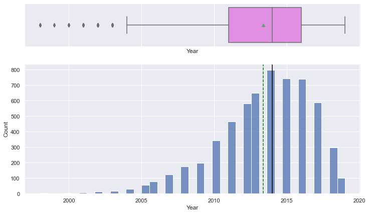

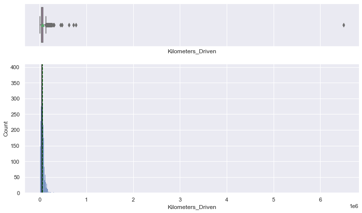

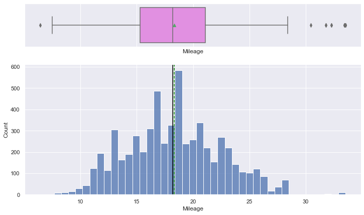

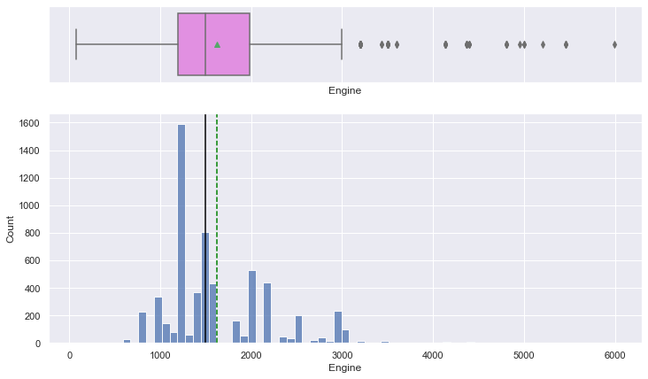

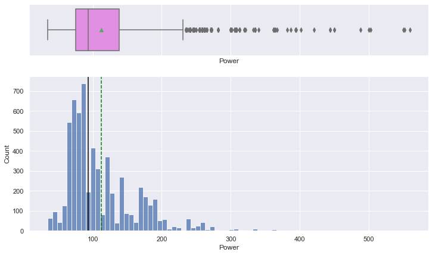

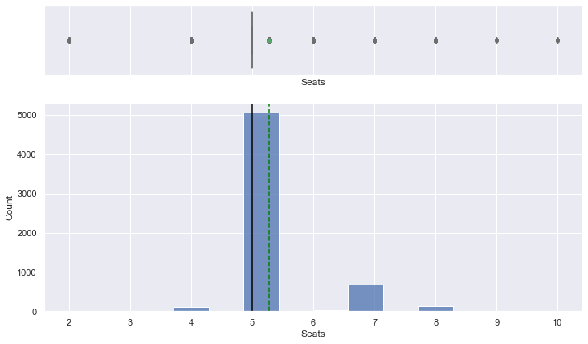

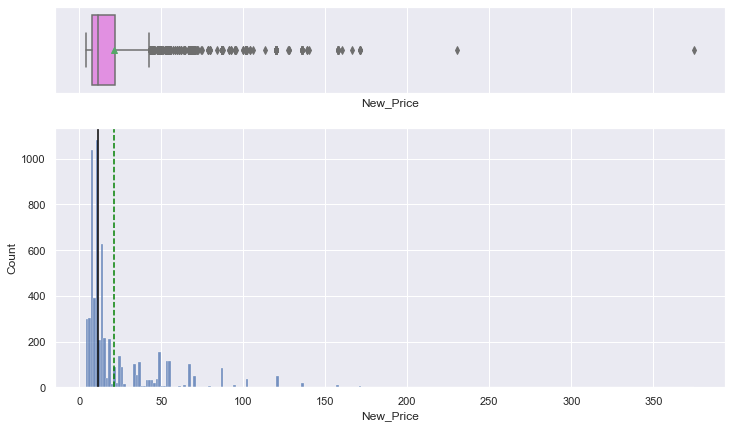

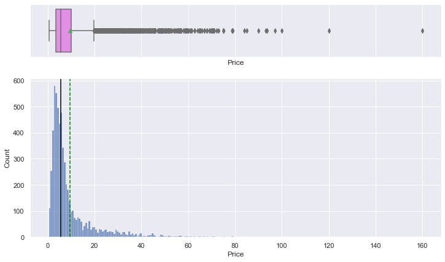

```python
#Create to both histgram and boxplot graph for all numerical columns.
for i in num_col:
    histogram_boxplot(df2, i) # Call hist_box function for each column.
```

*Observations on Data for Numerical variables*